# L2P1: Explorando marcas e canais - Lorena Pereira

```r
dados = read_csv(
    here::here("data/participation-per-country.csv"),
    col_types = cols(
        .default = col_double(),
        site = col_character(),
        country = col_character(),
        geo = col_character(),
        four_regions = col_character(),
        eight_regions = col_character(),
        six_regions = col_character(),
        `World bank income group 2017` = col_character()
    )
) %>%
    filter(usuarios > 200)

dados_filtrados <- dados %>%
    select(six_regions, country, site, usuarios, comentaram_prop, PDI, Internet) %>%
    filter(!is.na(Internet)) %>%
    filter(!is.na(six_regions))
```

## Quanto as pessoas de diferentes países comentam em questões de sites Q&A

Sites Q&A - Question & Answer (Perguntas e respostas) são aqueles sites onde vários usuários podem interagir tirando suas dúvidas sobre assuntos diversos. Partindo de uma base de dados com observações para os sites Stack Overflow e Super User buscamos entender melhor esse contexto. Aqui vamos analisar a participação via comentários de pessoa de diferentes países e examinar a relação entre a quantidade de comentários e outras variáveis listadas a seguir: - Quão hierárquicas são as relações em um país; - Quanto as pessoas tem acesso a Internet e - Quantidade de usuários naquela região.

Para isso construímos o seguinte gráfico:

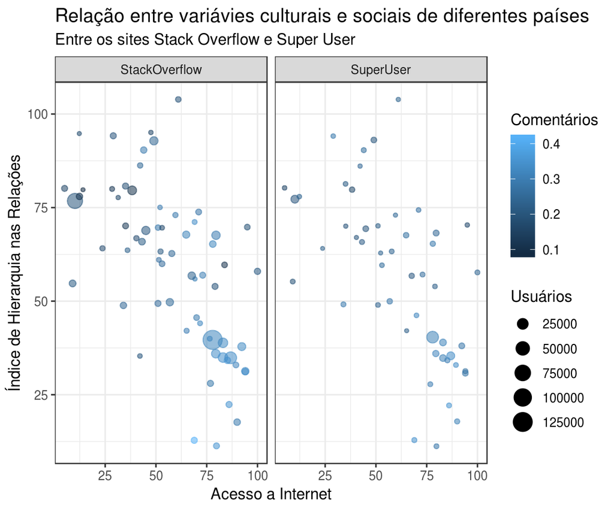

```r
dados_filtrados %>%
ggplot(mapping = aes(x = Internet, y = PDI)) +
    geom_jitter(aes(size = usuarios, alpha=.1, color = comentaram_prop)) +
    facet_grid(~ site) +
    ggtitle("Relação entre variávies culturais e sociais de diferentes países",
            subtitle="Entre os sites Stack Overflow e Super User") +
    labs(x="Acesso a Internet", y="Índice de Hierarquia nas Relações",
     colour = "Comentários", size = "Usuários") +
    guides(alpha = FALSE)
```

Com relação a quantidade de usuários podemos observar que o Stack Overflow apresenta mais exemplos de países que possuem mais usuários e que a maioria possuem acesso a Internet entre 75 e 100 e costumam comentar acima de 0,3 (numa escala de 0,1 e 0,4).

## Visualizações menos eficazes

#### Visualizando a hierarquia e a quantidade de usuários de todos os países em um gráfico de barras

Menos eficiente pois não esta ordenado e dificulta a comparação entre os países embora use o canal mais eficiente que é o de posições em uma escala comum. Essa visualização também só traz duas das variáveis solicitadas e por uma limitação da largura do gráfico os nomes dos países ficam bem próximos.

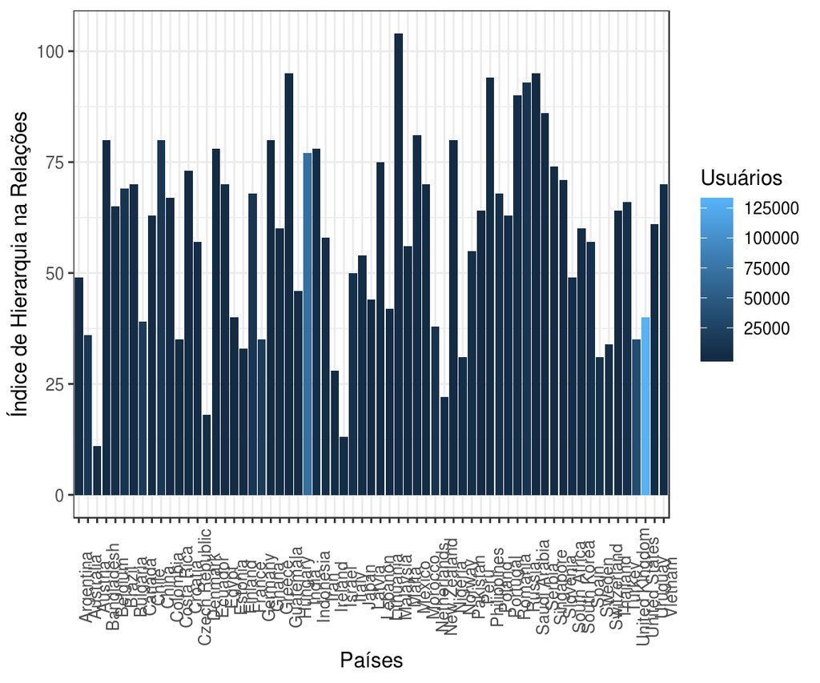

```r
dados_filtrados %>% filter(site == "StackOverflow") %>%
ggplot(mapping = aes(fill=usuarios, x = country, y = PDI)) +
    geom_bar(position="dodge", stat="identity") +
    theme(axis.text.x = element_text(angle = 90)) +
    labs(x="Países", y="Índice de Hierarquia na Relações", fill = "Usuários")
```

#### Visualizando a quantidade de usuários e a hierarquia de todos os países em um gráfico de barras

Menos eficiente pois não está ordenado e dificulta a comparação. Mas em comparação com a visualização anterior já fica mais fácil de visualizar qual paíse tem maior quantidade de uauários.

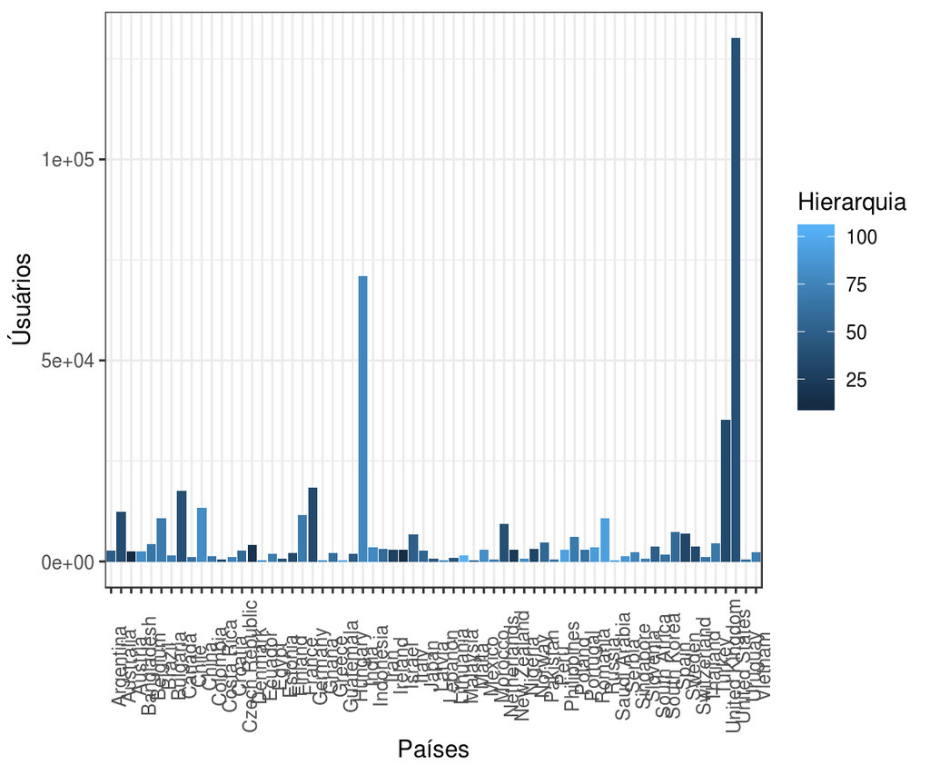

```r
dados_filtrados %>% filter(site == "StackOverflow") %>%
ggplot(mapping = aes(fill=PDI, x = country, y = usuarios)) +
    geom_bar(position="dodge", stat="identity") +
    theme(axis.text.x = element_text(angle = 90)) +
    labs(x="Países", y="Úsuários", fill = "Hierarquia")
```

#### Visualizando a hierarquia e a participação dos países em um gráfico de barras

Menos eficiente pois não esta ordenado e dificulta a comparação.

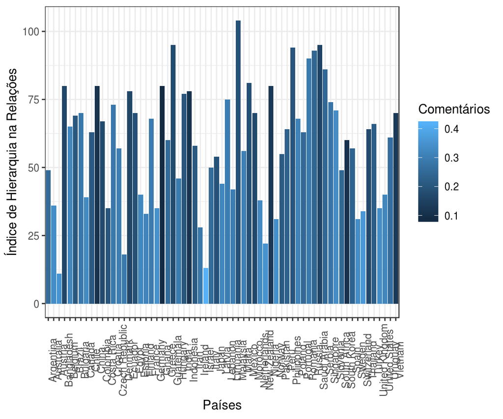

```r
dados_filtrados %>% filter(site == "StackOverflow") %>%
ggplot(mapping = aes(fill=comentaram_prop, x = country, y = PDI)) +
    geom_bar(position="dodge", stat="identity") +
    theme(axis.text.x = element_text(angle = 90)) +
    labs(x="Países", y="Índice de Hierarquia na Relações", fill = "Comentários")
```

#### Visualizando Usuários, Comentários e Acesso a Internet

Menos eficiente pois os atributos escolhidos para os canais deixam os itens mais sobrepostos visto que tem valores semelhantes.

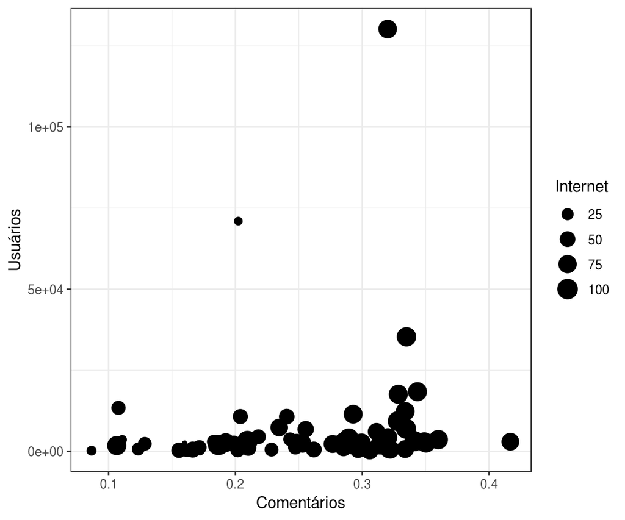

```r
dados_filtrados %>% filter(site == "StackOverflow") %>%
ggplot(mapping = aes(x = comentaram_prop, y = usuarios)) +
    geom_jitter(aes(size = Internet)) +
    labs(x="Comentários", y="Usuários", size = "Internet")
```

## Incluindo o continente dos países

Na visualização abaixo podemos observar as relações entre as variáveis citadas anteriormente com os países agrupados por continentes. Consideramos apenas o site Stack Overflow por ter maior quantidade de usuários. Desse forma é possível ver que a Europa e Ásia central tem uma maior quantidade de países que participam desses sites enquanto a África subsaariana apresenta o menor número de países participantes.

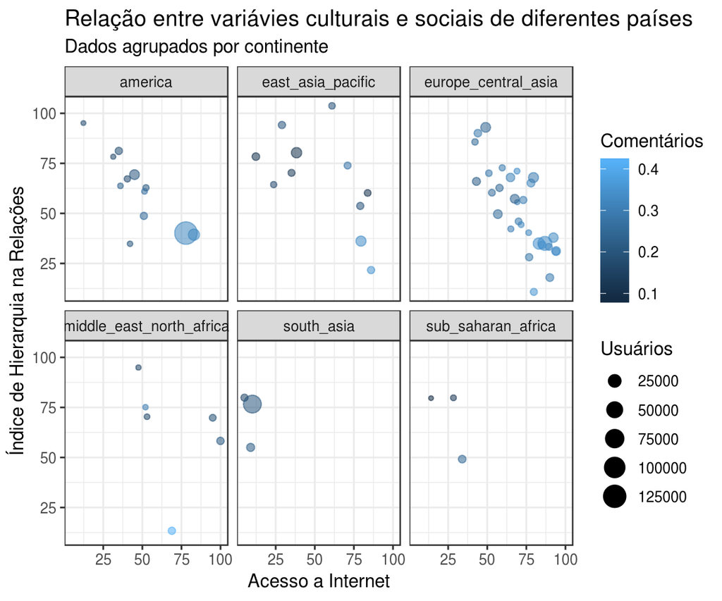

```r
dados_filtrados %>% filter(site == "StackOverflow") %>%
ggplot(mapping = aes(x = Internet, y = PDI)) +
    geom_jitter(aes(size = usuarios, alpha = 0.2, color = comentaram_prop)) +
    ggtitle("Relação entre variávies culturais e sociais de diferentes países",
            subtitle="Dados agrupados por continente") +
    labs(x="Acesso a Internet", y="Índice de Hierarquia na Relações",
         colour = "Comentários", size = "Usuários") +
    facet_wrap(~ six_regions, ncol(2)) +
    guides(alpha = FALSE)
```